# intento1_limpieza_con_sku

```r
a <- read_csv("project-objectstorage/VENTAS_CON_UBICACION_LIMPIO.csv")
a <- a %>% select(-plan_tarifario)
```

###*2. Transformación de variables*

**Paso 1:** Eliminar caracteres que pudieran haber prevalecido a lo largo de este proceso en la columna de plan tarifario, por ejemplo: comas.

```r
ventas_con_ubicacion_limpio<- a
#ventas_con_ubicacion_limpio$plan_tarifario<-gsub("[[:punct:]]", "", ventas_con_ubicacion_limpio$plan_tarifario)
```

Paso 2: Calcular el costo promedio de los productos

```r
costo_promedio <- ventas_con_ubicacion_limpio[,c(2,4)]%>%group_by(sku_por_equipo)%>%summarise(costo_promedio = mean(costo))
costo_promedio <- costo_promedio %>%arrange(sku_por_equipo)
costo_promedio
```

```
## # A tibble: 455 x 2
##    sku_por_equipo costo_promedio
##    <chr>                   <dbl>
##  1 N.6045I                  994.
##  2 N.6045ID                 932.
##  3 N.7P128RJ              16140
##  4 N.A475B                 1284.
##  5 N.A5054SD                617.
##  6 N.A5098OD               1241.
##  7 N.A5098ON               1411.
##  8 N.AA3PLNG               1578.
##  9 N.AIXR128A             15777.
## 10 N.AIXR128AZ            15955.
## # … with 445 more rows
```

Paso 3: imputar costo promedio y quedarse con esa nueva variableen lugar de costo

```r
ventas_con_ubicacion_limpio <- left_join(ventas_con_ubicacion_limpio, costo_promedio, by="sku_por_equipo")
ventas_con_ubicacion_limpio <- ventas_con_ubicacion_limpio %>% select(-costo)
ventas_con_ubicacion_limpio <- ventas_con_ubicacion_limpio %>% select(punto_de_venta, #plan_tarifario,
                                                                      sku_por_equipo, fecha, costo_promedio, marca, ventas, mes, anio, marca_modificada, estado, ciudad, latitud, longitud, zona)
```

**Paso 2:** Construir la variable gamma, dependiendo del costo de los productos y homogeneizar las familias de planes a 4 categorias.

```r
ventas_con_ubicacion_limpio <- ventas_con_ubicacion_limpio%>%mutate(gamma_de_acuerdo_a_costo=0, familia_de_planes = "compartelo_adicional")
head(ventas_con_ubicacion_limpio,10)
```

```
## # A tibble: 10 x 16
##    punto_de_venta sku_por_equipo fecha      costo_promedio marca ventas
##    <chr>          <chr>          <date>              <dbl> <chr>  <dbl>
##  1 1 poniente     N.HUM10LN      2018-06-01          4302. huaw…      1
##  2 1 poniente     N.MZ2PLYG      2018-06-01          4924. moto…      1
##  3 1 poniente     N.ZV8MNG       2018-06-01          2471. zte        1
##  4 1 poniente     N.ZV8MNG       2018-06-01          2471. zte        1
##  5 1 poniente     N.HUAP20N      2018-06-02          8746. huaw…      1
##  6 1 poniente     N.HUY9FLAZ     2018-06-02          2919. huaw…      1
##  7 1 poniente     N.HUY9FLADR    2018-06-04          2914. huaw…      1
##  8 1 poniente     N.MOTOCNG      2018-06-04           905. moto…      1
##  9 1 poniente     N.ZV8MNG       2018-06-04          2471. zte        1
## 10 1 poniente     N.HUY9FLAZ     2018-06-05          2919. huaw…      1
## # … with 10 more variables: mes <dbl>, anio <dbl>, marca_modificada <chr>,
## #   estado <chr>, ciudad <chr>, latitud <dbl>, longitud <dbl>, zona <chr>,
## #   gamma_de_acuerdo_a_costo <dbl>, familia_de_planes <chr>
```

**Paso 3:** Asignar los valores correspondientes a las dos columnas nuevas.

```r
#Registrar gamma
ventas_con_ubicacion_limpio$gamma_de_acuerdo_a_costo[which(ventas_con_ubicacion_limpio$costo_promedio<=5000)]<-"baja"
ventas_con_ubicacion_limpio$gamma_de_acuerdo_a_costo[which(ventas_con_ubicacion_limpio$costo_promedio>5000 & ventas_con_ubicacion_limpio$costo_promedio<=10000)]<-"media"
ventas_con_ubicacion_limpio$gamma_de_acuerdo_a_costo[which(ventas_con_ubicacion_limpio$costo_promedio>10000 & ventas_con_ubicacion_limpio$costo_promedio<=15000)]<-"alta"
ventas_con_ubicacion_limpio$gamma_de_acuerdo_a_costo[which(ventas_con_ubicacion_limpio$costo_promedio>15000)]<-"premium"
```

```r
ventas_con_ubicacion_limpio%>%select(gamma_de_acuerdo_a_costo)%>%group_by(gamma_de_acuerdo_a_costo)%>%unique()
```

```
## # A tibble: 4 x 1
## # Groups:   gamma_de_acuerdo_a_costo [4]
##   gamma_de_acuerdo_a_costo
##   <chr>
## 1 baja
## 2 media
## 3 premium
## 4 alta
```

```r
#which(is.na(ventas_con_ubicacion_limpio$gamma_de_acuerdo_a_costo)) #Todos ya tienen registrado una gamma
```

```r
#hay 455 productos con una gamma particular
ventas_con_ubicacion_limpio[,c(2,15)]%>%unique()
```

```
## # A tibble: 455 x 2
##    sku_por_equipo gamma_de_acuerdo_a_costo
##    <chr>          <chr>
##  1 N.HUM10LN      baja
##  2 N.MZ2PLYG      baja
##  3 N.ZV8MNG       baja
##  4 N.HUAP20N      media
##  5 N.HUY9FLAZ     baja
##  6 N.HUY9FLADR    baja
##  7 N.MOTOCNG      baja
##  8 N.MOG6PYI      baja
##  9 N.HUM10LA      baja
## 10 N.MOTOEAZ      baja
## # … with 445 more rows
```

```r
#Registrar familias de planes: hay 55 diferentes, sin embargo, se van a homogeneizar a 4.

#Familia PLus
#ventas_con_ubicacion_limpio$familia_de_planes[which(ventas_con_ubicacion_limpio$plan_tarifario=="att plus atmv1 199" |
                                                      #ventas_con_ubicacion_limpio$plan_tarifario=="att plus atmv1 239"|
                                                      #ventas_con_ubicacion_limpio$plan_tarifario=="att plus atmv1 299"|
                                                      #ventas_con_ubicacion_limpio$plan_tarifario=="att plus atmv1 399"|
                                                      #ventas_con_ubicacion_limpio$plan_tarifario=="att plus atmv1 499"|
                                                      #ventas_con_ubicacion_limpio$plan_tarifario=="att plus atmv1 699"|
                                                      #ventas_con_ubicacion_limpio$plan_tarifario=="att plus atmv1 999")
                                              #]<-"familia_plus"


#Famillila compartelo negocios
#ventas_con_ubicacion_limpio$familia_de_planes[which(ventas_con_ubicacion_limpio$plan_tarifario=="b compartelo incluido negocios" | ventas_con_ubicacion_limpio$plan_tarifario=="compartelo incluido negocios" | ventas_con_ubicacion_limpio$plan_tarifario=="b compartelo voz mensajes e internet negocios"| ventas_con_ubicacion_limpio$plan_tarifario=="compartelo voz mensajes e internet negocios")]<-"compartelo_negocios"


#familia de compartelo incluido
#ventas_con_ubicacion_limpio$familia_de_planes[which(ventas_con_ubicacion_limpio$plan_tarifario=="compartelo incluido voz sms y datos" | ventas_con_ubicacion_limpio$plan_tarifario=="compartelo incluido voz sms datos")]<-"compartelo_incluido"
```

```r
#ventas_con_ubicacion_limpio%>%select(familia_de_planes)%>%group_by(familia_de_planes)%>%unique()
#which(is.na(ventas_con_ubicacion_limpio$familia_de_planes)) #Todos ya tienen registrado una gamma
```

**Paso 4:** Seleccionar columnas.

```r
names(ventas_con_ubicacion_limpio)
```

```
##  [1] "punto_de_venta"           "sku_por_equipo"
##  [3] "fecha"                    "costo_promedio"
##  [5] "marca"                    "ventas"
##  [7] "mes"                      "anio"
##  [9] "marca_modificada"         "estado"
## [11] "ciudad"                   "latitud"
## [13] "longitud"                 "zona"
## [15] "gamma_de_acuerdo_a_costo" "familia_de_planes"
```

************se quita familia de planes

```r
datos_ventas_ubicacion_gamma_familia <- ventas_con_ubicacion_limpio %>% select(punto_de_venta,
                                                                               fecha,
                                                                               mes,
                                                                               anio,
                                                                               ventas,
                                                                               sku_por_equipo,
                                                                               marca_modificada,
                                                                               gamma_de_acuerdo_a_costo,
                                                                               #familia_de_planes,
                                                                               zona,
                                                                               estado,
                                                                               ciudad,
                                                                               latitud,
                                                                               longitud)

names(datos_ventas_ubicacion_gamma_familia) <- c("punto_de_venta", "fecha", "mes", "anio", "num_ventas", "sku", "marca","gamma", "zona", "estado", "ciudad", "latitud", "longitud")
```

```r
names(datos_ventas_ubicacion_gamma_familia)
```

```
##  [1] "punto_de_venta" "fecha"          "mes"            "anio"
##  [5] "num_ventas"     "sku"            "marca"          "gamma"
##  [9] "zona"           "estado"         "ciudad"         "latitud"
## [13] "longitud"
```

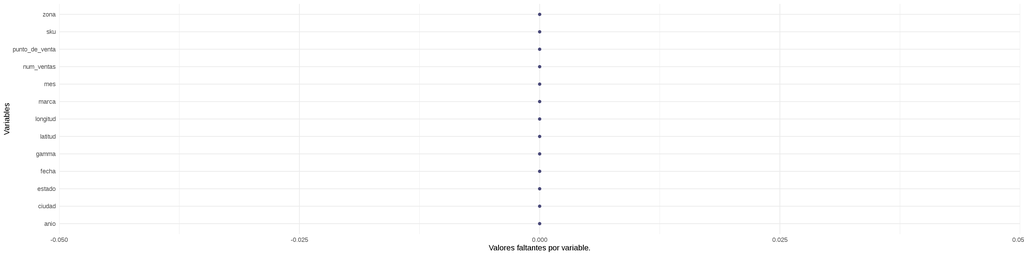

```r
gg_miss_var(datos_ventas_ubicacion_gamma_familia) + labs(y = "Valores faltantes por variable.")
```

```r
#write.csv(datos_ventas_ubicacion_gamma_familia, "DATOS_SEMI_COMPLETOS.csv", row.names = FALSE)
```

consideramos sku apartir de aqui 932,963 en lugar de 700 y algo _______________________________________________________________________

```r
#Calcular ventas por totales 932,963 en vez d 1048575
DATOS_LIMPIOS <- datos_ventas_ubicacion_gamma_familia%>%
  group_by(punto_de_venta, fecha, mes, anio, sku, marca, gamma, zona, estado, ciudad, latitud, longitud)%>%summarise(ventas_diarias = sum(num_ventas)) #se añadio mes y a{io y sku en comparacion con el archivo anteior}

DATOS_LIMPIOS
```

```
## # A tibble: 932,963 x 13
## # Groups:   punto_de_venta, fecha, mes, anio, sku, marca, gamma, zona,
## #   estado, ciudad, latitud [932,963]
##    punto_de_venta fecha        mes  anio sku   marca gamma zona  estado
##    <chr>          <date>     <dbl> <dbl> <chr> <chr> <chr> <chr> <chr>
##  1 1 poniente     2018-06-01     6  2018 N.HU… huaw… baja  cent… puebla
##  2 1 poniente     2018-06-01     6  2018 N.MZ… moto… baja  cent… puebla
##  3 1 poniente     2018-06-01     6  2018 N.ZV… zte   baja  cent… puebla
##  4 1 poniente     2018-06-02     6  2018 N.HU… huaw… media cent… puebla
##  5 1 poniente     2018-06-02     6  2018 N.HU… huaw… baja  cent… puebla
##  6 1 poniente     2018-06-04     6  2018 N.HU… huaw… baja  cent… puebla
##  7 1 poniente     2018-06-04     6  2018 N.MO… moto… baja  cent… puebla
##  8 1 poniente     2018-06-04     6  2018 N.ZV… zte   baja  cent… puebla
##  9 1 poniente     2018-06-05     6  2018 N.HU… huaw… baja  cent… puebla
## 10 1 poniente     2018-06-05     6  2018 N.MO… moto… baja  cent… puebla
## # … with 932,953 more rows, and 4 more variables: ciudad <chr>,
## #   latitud <dbl>, longitud <dbl>, ventas_diarias <dbl>
```

```r
#write.csv(DATOS_LIMPIOS, "DATOS_LIMPIOS.csv", row.names = FALSE)
```

###*3. Ingeniería de Características*

```r
datos <- DATOS_LIMPIOS
```

**Paso 1:** Construir índices

```r
#construccion de IDs
shopID <- datos[,1]%>%arrange(punto_de_venta)%>%unique() #1909 puntos de venta
shopID$tiendaID <- as.character(seq.int(nrow(shopID)))

marcaID <- datos[,6]%>%arrange(marca)%>%unique() #12 marcas
marcaID$marcaID <- as.character(seq.int(nrow(marcaID)))

gammaID <- datos[,7]%>%unique() #4 gammas
gammaID$gammaID <- as.character(c(1,2,4,3))

skuID <- datos[,5]%>%arrange(sku)%>%unique() #455 productos
skuID$skuID <- as.character(seq.int(nrow(skuID)))

fechaID <- datos[,3]%>%unique()
fechaID$fechaID <- as.character(seq.int(0,9,1))
```

```r
#ocnjunto de puntos de venta con su index
datos <- ungroup(datos)
shop_completar <- datos %>% select(punto_de_venta, zona, estado, ciudad, latitud, longitud)%>%unique() #1909 puntos de venta
shop_completar$tiendaID <- as.character(seq.int(nrow(shopID)))
```

**Paso 2:** Juntas ID’s con datos

```r
#juntas columnas con id en los datos 710,011 cambio a 932,963 cnsiderando sku y no plan tarifario
datos <- left_join(datos, shopID, by="punto_de_venta")
datos <- left_join(datos, marcaID, by="marca")
datos <- left_join(datos, gammaID, by="gamma")
datos <- left_join(datos, skuID, by="sku")
datos <- left_join(datos, fechaID, by="mes")
datos
```

```
## # A tibble: 932,963 x 18
##    punto_de_venta fecha        mes  anio sku   marca gamma zona  estado
##    <chr>          <date>     <dbl> <dbl> <chr> <chr> <chr> <chr> <chr>
##  1 1 poniente     2018-06-01     6  2018 N.HU… huaw… baja  cent… puebla
##  2 1 poniente     2018-06-01     6  2018 N.MZ… moto… baja  cent… puebla
##  3 1 poniente     2018-06-01     6  2018 N.ZV… zte   baja  cent… puebla
##  4 1 poniente     2018-06-02     6  2018 N.HU… huaw… media cent… puebla
##  5 1 poniente     2018-06-02     6  2018 N.HU… huaw… baja  cent… puebla
##  6 1 poniente     2018-06-04     6  2018 N.HU… huaw… baja  cent… puebla
##  7 1 poniente     2018-06-04     6  2018 N.MO… moto… baja  cent… puebla
##  8 1 poniente     2018-06-04     6  2018 N.ZV… zte   baja  cent… puebla
##  9 1 poniente     2018-06-05     6  2018 N.HU… huaw… baja  cent… puebla
## 10 1 poniente     2018-06-05     6  2018 N.MO… moto… baja  cent… puebla
## # … with 932,953 more rows, and 9 more variables: ciudad <chr>,
## #   latitud <dbl>, longitud <dbl>, ventas_diarias <dbl>, tiendaID <chr>,
## #   marcaID <chr>, gammaID <chr>, skuID <chr>, fechaID <chr>
```

```r
datos <- datos %>% select(fechaID, fecha, tiendaID, punto_de_venta, marcaID, marca, gammaID, gamma, skuID, sku, ventas_diarias, mes, anio)
```

```r
d <- datos[,c(5,7,9)]%>%select(skuID, marcaID,gammaID)%>%arrange(skuID)%>%unique()
```

**Paso 3:** Completar serie de tiempo

```r
a <- merge(fechaID, shopID)
b <- merge(a, d)
dim(b)
```

```
## [1] 8685950       7
```

```r
head(b)
```

```
##   mes fechaID punto_de_venta tiendaID skuID marcaID gammaID
## 1   6       0     1 poniente        1     1       2       1
## 2   7       1     1 poniente        1     1       2       1
## 3   8       2     1 poniente        1     1       2       1
## 4   9       3     1 poniente        1     1       2       1
## 5  10       4     1 poniente        1     1       2       1
## 6  11       5     1 poniente        1     1       2       1
```

```r
completar_serie_de_tiempo <- b %>% select(tiendaID, marcaID, skuID, gammaID, fechaID)
head(completar_serie_de_tiempo,10)
```

```
##    tiendaID marcaID skuID gammaID fechaID
## 1         1       2     1       1       0
## 2         1       2     1       1       1
## 3         1       2     1       1       2
## 4         1       2     1       1       3
## 5         1       2     1       1       4
## 6         1       2     1       1       5
## 7         1       2     1       1       6
## 8         1       2     1       1       7
## 9         1       2     1       1       8
## 10        1       2     1       1       9
```

**Paso 4:** Crear variable a predecir: ventas por mes (441,597)

```r
#calculamos ventas diarias por mes, tienda, marca, familia, gamma
medias <- datos %>% group_by(fechaID, tiendaID, marcaID, skuID, gammaID)%>%summarise(ventas_por_mes = sum(ventas_diarias))
```

```r
completar_serie_de_tiempo <- left_join(completar_serie_de_tiempo, medias, by=c("fechaID", "tiendaID", "marcaID", "skuID", "gammaID"))
```

```r
#which(is.na(completar_serie_de_tiempo$ventas_por_mes))
```

Los missings en ventas por mes corresponden a que no hubo ventas para esa marca, gamma, familia, en esa tienda y fecha; porlo tanto, sustituimos estos NA’s con 0.

```r
completar_serie_de_tiempo[is.na(completar_serie_de_tiempo)] <- 0
completar_serie_de_tiempo
```

```
##       tiendaID marcaID skuID gammaID fechaID ventas_por_mes
## 1            1       2     1       1       0              0
## 2            1       2     1       1       1              0
## 3            1       2     1       1       2              0
## 4            1       2     1       1       3              0
## 5            1       2     1       1       4              0
## 6            1       2     1       1       5              0
## 7            1       2     1       1       6              0
## 8            1       2     1       1       7              0
## 9            1       2     1       1       8              0
## 10           1       2     1       1       9              0
## 11           2       2     1       1       0              0
## 12           2       2     1       1       1              0
## 13           2       2     1       1       2              0
## 14           2       2     1       1       3              0
```

[output cut: 16653 more lines]

```r
sum(completar_serie_de_tiempo$ventas_por_mes)
```

```
## [1] 1048575
```

AQUI_________TITULACION

**Paso 5:** Crear nuevas características: Rezagos

Creamos las características de ventas promedio por mes, tienda y producto y ventas totales con las cuáles se crean las características que necesitamos de manera rezagada más adelante.

```r
e<-datos%>%
  group_by(fechaID, tiendaID)%>%
  summarise(ventas_totales_por_tienda_por_mes=sum(ventas_diarias),
            ventas_promedio_por_tienda_por_mes = mean(ventas_diarias))
```

```r
f<-datos%>%
  group_by(fechaID, marcaID)%>%
  summarise(ventas_totales_por_marca_por_mes=sum(ventas_diarias),
            ventas_promedio_por_marca_por_mes = mean(ventas_diarias))
```

```r
g<-datos%>%
  group_by(fechaID, gammaID)%>%
  summarise(ventas_totales_por_gamma_por_mes=sum(ventas_diarias),
            ventas_promedio_por_gamma_por_mes = mean(ventas_diarias))
```

```r
h<-datos%>%
  group_by(fechaID, skuID)%>%
  summarise(ventas_totales_por_sku_por_mes=sum(ventas_diarias),
            ventas_promedio_por_sku_por_mes = mean(ventas_diarias))
```

```r
completar_serie_de_tiempo <- left_join(completar_serie_de_tiempo, e, by=c("tiendaID","fechaID"))
completar_serie_de_tiempo <- left_join(completar_serie_de_tiempo, f, by=c("marcaID","fechaID"))
completar_serie_de_tiempo <- left_join(completar_serie_de_tiempo, g, by=c("gammaID","fechaID"))
completar_serie_de_tiempo <- left_join(completar_serie_de_tiempo, h, by=c("skuID","fechaID"))
head(completar_serie_de_tiempo,10)
```

```
##    tiendaID marcaID skuID gammaID fechaID ventas_por_mes
## 1         1       2     1       1       0              0
## 2         1       2     1       1       1              0
## 3         1       2     1       1       2              0
## 4         1       2     1       1       3              0
## 5         1       2     1       1       4              0
## 6         1       2     1       1       5              0
## 7         1       2     1       1       6              0
## 8         1       2     1       1       7              0
## 9         1       2     1       1       8              0
## 10        1       2     1       1       9              0
##    ventas_totales_por_tienda_por_mes ventas_promedio_por_tienda_por_mes
## 1                                 70                           1.044776
## 2                                 79                           1.128571
## 3                                 87                           1.060976
```

[output cut: 40 more lines]

```r
completar_serie_de_tiempo[is.na(completar_serie_de_tiempo)] <- 0
```

```r
completar_serie_de_tiempo_1 <- left_join(completar_serie_de_tiempo, shop_completar, by="tiendaID")
head(completar_serie_de_tiempo_1,10)
```

```
##    tiendaID marcaID skuID gammaID fechaID ventas_por_mes
## 1         1       2     1       1       0              0
## 2         1       2     1       1       1              0
## 3         1       2     1       1       2              0
## 4         1       2     1       1       3              0
## 5         1       2     1       1       4              0
## 6         1       2     1       1       5              0
## 7         1       2     1       1       6              0
## 8         1       2     1       1       7              0
## 9         1       2     1       1       8              0
## 10        1       2     1       1       9              0
##    ventas_totales_por_tienda_por_mes ventas_promedio_por_tienda_por_mes
## 1                                 70                           1.044776
## 2                                 79                           1.128571
## 3                                 87                           1.060976
```

[output cut: 51 more lines]

**DATOS SIN LAGS**

```r
#write.csv(completar_serie_de_tiempo_1,file="DATOS_SIN_LAGS_PARA_DB.csv",row.names = FALSE)
```

**Paso 6:** Crear rezagos 3:18 . 3:19

```r
x <- completar_serie_de_tiempo%>%
  group_by(tiendaID, marcaID, skuID, gammaID)%>%
  mutate(lag1mes_ventas_totales_por_tienda_por_mes=dplyr::lag(ventas_totales_por_tienda_por_mes, n=1),
         lag1mes_ventas_promedio_por_tienda_por_mes=dplyr::lag(ventas_promedio_por_tienda_por_mes, n=1),
         lag1mes_ventas_totales_por_marca_por_mes=dplyr::lag(ventas_totales_por_marca_por_mes, n=1),
         lag1mes_entas_promedio_por_marca_por_mes=dplyr::lag(ventas_promedio_por_marca_por_mes, n=1),
         lag1mes_ventas_totales_por_gamma_por_mes=dplyr::lag(ventas_totales_por_gamma_por_mes, n=1),
         lag1mes_ventas_promedio_por_gamma_por_mes=dplyr::lag(ventas_promedio_por_gamma_por_mes, n=1),
         lag1mes_ventas_totales_por_sku_por_mes=dplyr::lag(ventas_totales_por_sku_por_mes, n=1),
         lag1mes_ventas_promedio_por_sku_por_mes=dplyr::lag(ventas_promedio_por_sku_por_mes, n=1),

         lag2mes_ventas_totales_por_tienda_por_mes=dplyr::lag(ventas_totales_por_tienda_por_mes, n=2),
         lag2mes_ventas_promedio_por_tienda_por_mes=dplyr::lag(ventas_promedio_por_tienda_por_mes, n=2),
         lag2mes_ventas_totales_por_marca_por_mes=dplyr::lag(ventas_totales_por_marca_por_mes, n=2),
         lag2mes_entas_promedio_por_marca_por_mes=dplyr::lag(ventas_promedio_por_marca_por_mes, n=2),
         lag2mes_ventas_totales_por_gamma_por_mes=dplyr::lag(ventas_totales_por_gamma_por_mes, n=2),
         lag2mes_ventas_promedio_por_gamma_por_mes=dplyr::lag(ventas_promedio_por_gamma_por_mes, n=2),
         lag2mes_ventas_totales_por_sku_por_mes=dplyr::lag(ventas_totales_por_sku_por_mes, n=2),
         lag2mes_ventas_promedio_por_sku_por_mes=dplyr::lag(ventas_promedio_por_sku_por_mes, n=2),

         lag3mes_ventas_totales_por_tienda_por_mes=dplyr::lag(ventas_totales_por_tienda_por_mes, n=3),
         lag3mes_ventas_promedio_por_tienda_por_mes=dplyr::lag(ventas_promedio_por_tienda_por_mes, n=3),
         lag3mes_ventas_totales_por_marca_por_mes=dplyr::lag(ventas_totales_por_marca_por_mes, n=3),
         lag3mes_entas_promedio_por_marca_por_mes=dplyr::lag(ventas_promedio_por_marca_por_mes, n=3),
         lag3mes_ventas_totales_por_gamma_por_mes=dplyr::lag(ventas_totales_por_gamma_por_mes, n=3),
         lag3mes_ventas_promedio_por_gamma_por_mes=dplyr::lag(ventas_promedio_por_gamma_por_mes, n=3),
         lag3mes_ventas_totales_por_sku_por_mes=dplyr::lag(ventas_totales_por_sku_por_mes, n=3),
         lag3mes_ventas_promedio_por_sku_por_mes=dplyr::lag(ventas_promedio_por_sku_por_mes, n=3))
```

**Paso 7:** completar lag con valores iniciales (5:55-5:56)

```r
yy<-na.locf(x, fromLast = TRUE)
```

```r
#write.csv(yy,file="DATOS_CON_LAGS.csv",row.names = FALSE)
```

**Paso 8:** Formato para modelo

Quitar todos los datos que no se tendrán al momento de hacer la predicción. Conservar:

```r
#DATOS_LISTOS_MODELADO_REZAGOS <- yy%>%select(-ventas_totales_por_tienda_por_mes, -ventas_promedio_por_tienda_por_mes, -ventas_totales_por_marca_por_mes, -ventas_promedio_por_marca_por_mes, -ventas_totales_por_gamma_por_mes, -ventas_promedio_por_gamma_por_mes, -ventas_totales_por_sku_por_mes, -ventas_promedio_por_sku_por_mes)
```

**Paso 9:** Añadir las variables faltantes relacionadas con la ubicación de los puntos de venta para mapa

```r
#DATOS_COMPLETOS_XGBOOST_MAPA <- left_join(DATOS_LISTOS_MODELADO_REZAGOS, shop_completar, by="tiendaID")
```

**Paso 10:** Guardar los archivos

crear variable y

```r
shift<-function(x,shift_by){
    stopifnot(is.numeric(shift_by))
    stopifnot(is.numeric(x))

    if (length(shift_by)>1)
        return(sapply(shift_by,shift, x=x))

    out<-NULL
    abs_shift_by=abs(shift_by)
    if (shift_by > 0 )
        out<-c(tail(x,-abs_shift_by),rep(NA,abs_shift_by))
    else if (shift_by < 0 )
        out<-c(rep(NA,abs_shift_by), head(x,-abs_shift_by))
    else
        out<-x
    out
}
```

3:32

```r
datos_titulacion <- yy%>%
  group_by(tiendaID, marcaID, skuID, gammaID)%>%
  mutate(variable_y_ventas_del_siguiente_mes=shift(ventas_por_mes,1))

#names(datos_titulacion)

datos_titulacion <- datos_titulacion %>%select("tiendaID",
                                               "marcaID", "skuID", "gammaID", "fechaID", "ventas_por_mes","variable_y_ventas_del_siguiente_mes", "ventas_totales_por_tienda_por_mes","ventas_promedio_por_tienda_por_mes", "ventas_totales_por_marca_por_mes","ventas_promedio_por_marca_por_mes",
"ventas_totales_por_gamma_por_mes","ventas_promedio_por_gamma_por_mes",
"ventas_totales_por_sku_por_mes","ventas_promedio_por_sku_por_mes",
"lag1mes_ventas_totales_por_tienda_por_mes","lag1mes_ventas_promedio_por_tienda_por_mes",
"lag1mes_ventas_totales_por_marca_por_mes","lag1mes_entas_promedio_por_marca_por_mes",
"lag1mes_ventas_totales_por_gamma_por_mes","lag1mes_ventas_promedio_por_gamma_por_mes",
"lag1mes_ventas_totales_por_sku_por_mes","lag1mes_ventas_promedio_por_sku_por_mes",
"lag2mes_ventas_totales_por_tienda_por_mes","lag2mes_ventas_promedio_por_tienda_por_mes",
"lag2mes_ventas_totales_por_marca_por_mes","lag2mes_entas_promedio_por_marca_por_mes",
"lag2mes_ventas_totales_por_gamma_por_mes","lag2mes_ventas_promedio_por_gamma_por_mes",
"lag2mes_ventas_totales_por_sku_por_mes","lag2mes_ventas_promedio_por_sku_por_mes",
"lag3mes_ventas_totales_por_tienda_por_mes","lag3mes_ventas_promedio_por_tienda_por_mes",
"lag3mes_ventas_totales_por_marca_por_mes","lag3mes_entas_promedio_por_marca_por_mes",
"lag3mes_ventas_totales_por_gamma_por_mes","lag3mes_ventas_promedio_por_gamma_por_mes",
"lag3mes_ventas_totales_por_sku_por_mes","lag3mes_ventas_promedio_por_sku_por_mes")
```

```r
#write.csv(datos_titulacion,file="DATOS_COMPLETOS_FINALES_TITULACION_PARA_MODELOS.csv", row.names=FALSE)
```

> **PARA EL MODELO TENEMOS TENEMOS 39 VARIABLES, 3 REZAGOS, 8 CONTEOS DISTINTOS.**